# Data Wrangling - Analysis and insights

. . .

## Author : Suresh Lokiah

## Scope:

Perform Gather, Assess, Clean and visualization on data obtained from WeRateDogs Twitter archive that rates dogs on and has unique rating system.

The data is gathered from 3 data sources

1. twitter-archive-enhanced - contains tweet data for 5000+ tweets. It has 'text'field of the tweet and dog "stage" fields (i.e. doggo, floofer, pupper, and puppo)
2. Image Predcitions - Each image from the Tweet is processed using neural network to classify the dog breed using 3 predcitions (p1, p2, p3)
3. Tweet_json - downloaded the data that was gathered using Twitter API. This data has the retweet_count and favorite_count

## Assessing Data

Each dataset was systematically reviewed and, observations, quality and tidyness issues  
were documented at each step. Additionally, the step also makes guidance to "Next Step".  
So here is the format

- Observation
  - This section captures the observations made
- Quality
  - This captures the quality issues noted
- Tidyness
  - This captures the Tidyness issues
- Next Step
  - Guides to the next steps being performed

The following Quality and Tidyness issues were observed after assessing the datasets

#### Issues

##### Quality

`twitter-archive-enhanced.csv`

1. **Incorrect datatype** -
   1. **Number fields to Strings** - The following fields have a number datatype - tweet_id, in_reply_to_status_id, in_reply_to_user_id, retweeted_status_id, retweeted_status_user_id. These must all be String as there is no numerical calculations needed on those.
   2. **Object field must be datetime** - The timestamp, retweeted_status_timestamp must be datetime type
2. Column `tweet_id` must be a string
3. Column `in_reply_to_status_id` must be a string
4. Column `in_reply_to_user_id` must be a string
5. Fix column name Floofer as Floof
6. Fix values in column Floofer to floof
7. Create a column as dogtype and fill the value by parsing it from `text` field
8. Fix Non-name Dog names from `text` field.
9. Fix 'None' name from the text field
10. 84% of rows have unknown dog type
11. Replace string(None) to literal None

`image-predictions.tsv`

1. `tweet_id` must be string
2. Fix Dog type

`tweet-json.txt`

1. Fix `id` column and type

##### Tidyness

1. **Combine Table** - Looks like we can join the dataframes (df_twitter, df_image*predictions, df* tweet_json ) using tweet_id
2. Drop the column img_num

## Cleaning the data

A cloned copy of each dataframe was made with suffix "_clean" and was used to clean the data.

The following types of cleaning was performed on the data -

`image_predictions`

1. Fix Columns - tweet_id
2. Fix dog breed

`tweet_json`

1. Fix column name - id
2. Fix column type - tweet_id

And,

1. Combining the dataframes
2. Drop the img_num column

The resulting clean data was archived into 'twitter_archive_master.csv' file for visualization.

## Visualization

Using the data gathered, assesed and clean the following visualizations were deveopled.

1. Popular Dog names (Bar Plot)
2. Popular Dog breed(Bar Plot)
3. Retweet Count vs Favorite Count (Scatter Plot)

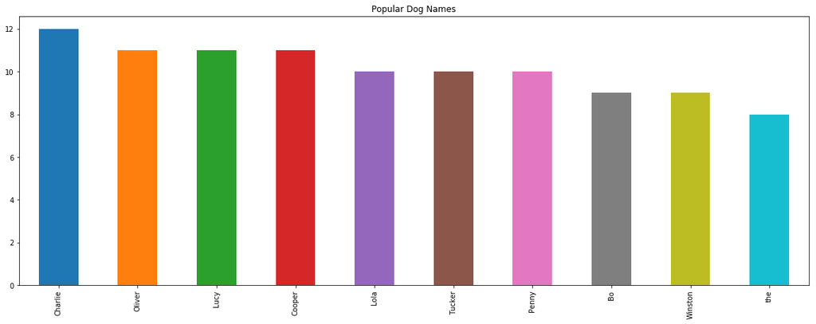

The above chart shows popular (top 3) dog names as

1. Charlie
2. Oliver
3. Lucy.

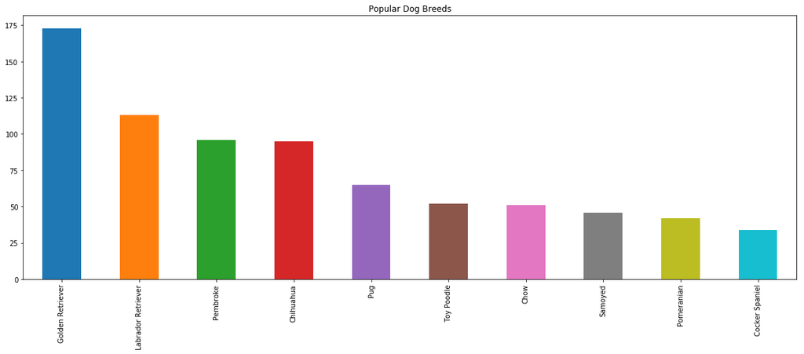

The above chart shows popular (top 3) dog breeds as

1. Golden Retriever
2. Labrador Retriever
3. Pembroke

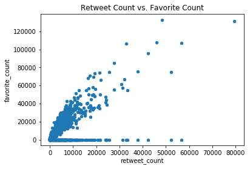

The above scatter plot shows the relationship between favorite count and retweet count.

## Summary

This exercise to Assess, Clean and Visualize the data fulfils the scope and provided good learning opportunity that will come in handy in a realworld dataset.